# Project Python Foundations: FoodHub Data Analysis

**Marks: 60**

### Context

The number of restaurants in New York is increasing day by day. Lots of students and busy professionals rely on those restaurants due to their hectic lifestyles. Online food delivery service is a great option for them. It provides them with good food from their favorite restaurants. A food aggregator company FoodHub offers access to multiple restaurants through a single smartphone app.

The app allows the restaurants to receive a direct online order from a customer. The app assigns a delivery person from the company to pick up the order after it is confirmed by the restaurant. The delivery person then uses the map to reach the restaurant and waits for the food package. Once the food package is handed over to the delivery person, he/she confirms the pick-up in the app and travels to the customer's location to deliver the food. The delivery person confirms the drop-off in the app after delivering the food package to the customer. The customer can rate the order in the app. The food aggregator earns money by collecting a fixed margin of the delivery order from the restaurants.

### Objective

The food aggregator company has stored the data of the different orders made by the registered customers in their online portal. They want to analyze the data to get a fair idea about the demand of different restaurants which will help them in enhancing their customer experience. Suppose you are hired as a Data Scientist in this company and the Data Science team has shared some of the key questions that need to be answered. Perform the data analysis to find answers to these questions that will help the company to improve the business.

### Data Description

The data contains the different data related to a food order. The detailed data dictionary is given below.

### Data Dictionary

- order_id: Unique ID of the order
- customer_id: ID of the customer who ordered the food
- restaurant_name: Name of the restaurant
- cuisine_type: Cuisine ordered by the customer
- cost: Cost of the order
- day_of_the_week: Indicates whether the order is placed on a weekday or weekend (The weekday is from Monday to Friday and the weekend is Saturday and Sunday)
- rating: Rating given by the customer out of 5
- food_preparation_time: Time (in minutes) taken by the restaurant to prepare the food. This is calculated by taking the difference between the timestamps of the restaurant's order confirmation and the delivery person's pick-up confirmation.
- delivery_time: Time (in minutes) taken by the delivery person to deliver the food package. This is calculated by taking the difference between the timestamps of the delivery person's pick-up confirmation and drop-off information

### Let us start by importing the required libraries

```python
# import libraries for data manipulation
import numpy as np
import pandas as pd

# import libraries for data visualization
import matplotlib.pyplot as plt
import seaborn as sns

# Seaborn aesthethic settings. Source: https://seaborn.pydata.org/examples/ (seaborn example gallery)
sns.set_theme(style='darkgrid')

# "Magic" command to tell Python to actually display the graphs (sourced from cases and session notebooks)
%matplotlib inline

# Option to display values up to 2 decimal places (sourced from cases and session notebooks)
pd.set_option("display.float_format", lambda x: "%.2f" % x)
```

### Understanding the structure of the data

```python
# uncomment and run the following lines for Google Colab
# from google.colab import drive
# drive.mount('/content/drive')
```

```python
# read the data
# Comment: this notebook was run on Jupyter. If this code is run on Colab, the following file path has to be edited accordingly.
df = pd.read_csv('foodhub_order.csv')
# returns the first 5 rows
df.head()
```

|  | order_id | customer_id | restaurant_name | cuisine_type | cost_of_the_order | day_of_the_week | rating | food_preparation_time | delivery_time |
| --- | --- | --- | --- | --- | --- | --- | --- | --- | --- |
| 0 | 1477147 | 337525 | Hangawi | Korean | 30.75 | Weekend | Not given | 25 | 20 |
| 1 | 1477685 | 358141 | Blue Ribbon Sushi Izakaya | Japanese | 12.08 | Weekend | Not given | 25 | 23 |
| 2 | 1477070 | 66393 | Cafe Habana | Mexican | 12.23 | Weekday | 5 | 23 | 28 |
| 3 | 1477334 | 106968 | Blue Ribbon Fried Chicken | American | 29.20 | Weekend | 3 | 25 | 15 |
| 4 | 1478249 | 76942 | Dirty Bird to Go | American | 11.59 | Weekday | 4 | 25 | 24 |

#### Observations:

The DataFrame has 9 columns as mentioned in the Data Dictionary. Data in each row corresponds to the order placed by a customer.

**Extra observation:** We can already observe that there are records where the customer didn't leave a rating.

### **Question 1:** How many rows and columns are present in the data? [0.5 mark]

```python
# Write your code here
print(f'Rows:\t\t{df.shape[0]}', f'Columns:\t{df.shape[1]}', sep = '\n')
```

```
Rows:		1898
Columns:	9
```

#### Observations:

The loaded data set has 9 columns (fields) and 1898 rows (records).

### **Question 2:** What are the datatypes of the different columns in the dataset? (The info() function can be used) [0.5 mark]

```python
# Use info() to print a concise summary of the DataFrame
df.info()
```

```
<class 'pandas.core.frame.DataFrame'>
RangeIndex: 1898 entries, 0 to 1897
Data columns (total 9 columns):
 #   Column                 Non-Null Count  Dtype
---  ------                 --------------  -----
 0   order_id               1898 non-null   int64
 1   customer_id            1898 non-null   int64
 2   restaurant_name        1898 non-null   object
 3   cuisine_type           1898 non-null   object
 4   cost_of_the_order      1898 non-null   float64
 5   day_of_the_week        1898 non-null   object
 6   rating                 1898 non-null   object
 7   food_preparation_time  1898 non-null   int64
 8   delivery_time          1898 non-null   int64
dtypes: float64(1), int64(4), object(4)
memory usage: 133.6+ KB
```

#### Observations:

- The data set has 9 fields (columns) of data, of which 5 are numerical.
- order_id and customer_id are recorded as numerical (integers).
- Order cost (cost_of_the_order) is registered as float.
- Time variables (food_preparation_time and delivery_time) are considered as integer quantities of minutes.
- The rest of the columns: restaurant_name, cuisine_type, day_of_the_week, and (counter-intuitively) rating, are registered as strings.
- No null values among the rows. More analysis is needed to verify the "sanity" of the data.

### **Question 3:** Are there any missing values in the data? If yes, treat them using an appropriate method. [1 mark]

```python
# Write your code here
df.isnull().sum()
```

```
order_id                 0
customer_id              0
restaurant_name          0
cuisine_type             0
cost_of_the_order        0
day_of_the_week          0
rating                   0
food_preparation_time    0
delivery_time            0
dtype: int64
```

#### Observations:

- The standard method to detect null values returns no nulls.
- This, *per se*, doesn't mean the data is reliable or that there are not invalid entries.

**More in depth analysis is required:**

**1. List of restaurant names:**

```python
rest_lst = np.sort(df['restaurant_name'].unique())
print (rest_lst)
```

```
["'wichcraft" '12 Chairs' '5 Napkin Burger' '67 Burger' 'Alidoro' 'Amma'
 "Amy Ruth's" 'Anjappar Chettinad' 'Asuka Sushi' 'Aurora' 'Balade'
 'Balthazar Boulangerie' 'Barbounia' 'Bareburger' 'Benihana'
 'Bhatti Indian Grill' "Big Daddy's" 'Big Wong Restaurant \x8c_¤¾Ñ¼'
 'Bistango' 'Blue Ribbon Brooklyn' 'Blue Ribbon Fried Chicken'
 'Blue Ribbon Sushi' 'Blue Ribbon Sushi Bar & Grill'
 'Blue Ribbon Sushi Izakaya' 'Boqueria' "Bubby's " 'Bukhara Grill'
 'Burger Joint' 'Byblos Restaurant' 'Cafe Habana' 'Cafe Mogador'
 'Cafe de La Esquina' 'Cafeteria' 'CafÌ© China' "Carmine's"
 'Chipotle Mexican Grill $1.99 Delivery' 'Cho Dang Gol'
 'Chola Eclectic Indian Cuisine' 'Chote Nawab' 'Cipriani Le Specialita'
 "Coppola's East" 'Crema Restaurante' 'Delicatessen' 'DespaÌ±a'
 "Dickson's Farmstand Meats" 'Dig Inn Seasonal Market'
 'Dirty Bird To Go (archived)' 'Dirty Bird to Go'
 "Don's Bogam BBQ & Wine Bar" 'Donburi-ya' 'Dos Caminos'
 'Dos Caminos Soho' 'DuMont Burger' 'El Parador Cafe'
 'Empanada Mama (closed)' 'Emporio' 'Five Guys Burgers and Fries'
 'Five Leaves' 'Frank Restaurant' 'Friend of a Farmer' 'Gaia Italian Cafe'
 'Galli Restaurant' 'Go! Go! Curry!' 'Grand Sichuan International'
 'Haandi' 'Hampton Chutney Co.' 'Han Dynasty' 'Hangawi'
 'Haru Gramercy Park' 'Hatsuhana' 'Haveli Indian Restaurant' 'Hibino'
 'Hill Country Fried Chicken' "Hiroko's Place" 'Hot Kitchen'
 'Hummus Place' 'Hunan Manor' 'Il Bambino' 'Izakaya Ten' 'J. G. Melon'
 "Jack's Wife Freda" "Joe's Shanghai \x8e_À\x8eü£¾÷´" 'Junoon'
 'Kambi Ramen House' 'Kanoyama' 'Klong' 'Kori Restaurant and Bar'
 "L'Express" 'La Follia' 'Lamarca Pasta' 'Lantern Thai Kitchen'
 'Le Grainne Cafe' 'Le Zie 2000 Trattoria' 'Lucky Strike'
 "Lucky's Famous Burgers" "Mamoun's Falafel" 'Market Table' 'Melt Shop'
 'Mira Sushi' 'Mission Cantina' 'Momoya' 'Moonstruck on Second'
 'Nha Trang One' 'Nobu Next Door' 'Olea' 'Olive Garden' 'Osteria Morini'
 'Otto Enoteca Pizzeria' "P.J. Clarke's" 'Parm' "Paul & Jimmy's"
 'Pepe Giallo' 'Pepe Rosso To Go' 'Philippe Chow' 'Piccolo Angolo'
 'Pinto Nouveau Thai Bistro' 'Pongsri Thai' 'Posto' 'Prosperity Dumpling'
 'Pylos' 'Ravagh Persian Grill' 'RedFarm Broadway' 'RedFarm Hudson'
 'Rohm Thai' 'Room Service' 'Rubirosa' 'Rye House' "S'MAC" 'Samurai Mama'
 "Sarabeth's" "Sarabeth's East" "Sarabeth's Restaurant" "Sarabeth's West"
 'Saravanaa Bhavan' "Schnipper's Quality Kitchen"
 'Serafina Fabulous Pizza' 'Shake Shack' 'Socarrat Paella Bar'
 'Song Thai Restaurant & Bar' 'Spice Thai' 'Sushi Choshi' 'Sushi Samba'
 'Sushi of Gari' 'Sushi of Gari 46' 'Sushi of Gari Tribeca' 'TAO'
 'Tamarind TriBeCa' 'Tarallucci e Vino Restaurant' 'Taro Sushi'
 'Terakawa Ramen' 'The Kati Roll Company' 'The Loop' 'The MasalaWala'
 'The Meatball Shop' 'The Odeon' 'The Smile' "Tony's Di Napoli" 'Tortaria'
 'Tres Carnes' 'UVA Wine Bar & Restaurant' 'V-Nam Cafe'
 "Vanessa's Dumpling House" "Vanessa's Dumplings" 'Vezzo Thin Crust Pizza'
 'Wa Jeal' 'Waverly Diner' 'Westville Hudson' 'Wo Hop Restaurant'
 'Woorijip' 'Xe May Sandwich Shop' "Xi'an Famous Foods" 'Yama 49'
 'Yama Japanese Restaurant' 'Zero Otto Nove' 'brgr' 'da Umberto'
 'ilili Restaurant' 'indikitch']
```

**Extra Observations about the restaurant names column:**

- A thorough observation of the restaurant list lets us know there are indeed problems and opportunities hidden in this field of data:

a) Some names seem to be duplicated with "alternative" spellings, like 'Blue Ribbon Brooklyn' and 'Blue Ribbon Fried Chicken'; 'Blue Ribbon Sushi', 'Blue Ribbon Sushi Bar & Grill', and 'Blue Ribbon Sushi Izakaya' (In fact the word "izakaya" is japanese that roughly translates as "bar" or "pub", so the last 3 names might very well be the same business); "Vanessa's Dumpling House" and "Vanessa's Dumplings", among others. However, before discarding, grouping, or renaming the apparent duplicates a little extra research is required. For the scope of this project, this list will not be modified.

b) There might be special character issues with some names (maybe chinese and spanish).

c) Some names include commentary like "(closed)" which could be put in a separate column and enrich the data analysis with extra insights, like as follows:

```python
df['Closed'] = [1 if df['restaurant_name'][idx].find('closed')!=-1 else 0 for idx in range(df.shape[0])] # new column with a dummy variable (1 = 'closed')

closed_orders = df[df['Closed']==1].shape[0] # Count of orders from "closed" restaurants

pct_cl_od = round(closed_orders/df.shape[0]*100,2) # % of orders from "closed" restaurants

closed_rest_str = ", ".join(df[df['Closed']==1]['restaurant_name'].unique()) # if more than one, they will show up as a string separated by commas.

print (f'{closed_orders} orders ({pct_cl_od}%) are from closed restaurants: {closed_rest_str}')
```

```
13 orders (0.68%) are from closed restaurants: Empanada Mama (closed)
```

Luckily the number of rows with this particular issue are very few, and won't affect the analysis in a significant way.

There's also an "archived" for a repeated restaurant name which will be ignored for lack of better information.

**2. Cuisine Type & Day of the Week:**

```python
df['cuisine_type'].unique()
```

```
array(['Korean', 'Japanese', 'Mexican', 'American', 'Indian', 'Italian',
       'Mediterranean', 'Chinese', 'Middle Eastern', 'Thai', 'Southern',
       'French', 'Spanish', 'Vietnamese'], dtype=object)
```

```python
df['day_of_the_week'].unique()
```

```
array(['Weekend', 'Weekday'], dtype=object)
```

No apparent issues with these two columns.

**3. Ratings:**

```python
df['rating'].unique()
```

```
array(['Not given', '5', '3', '4'], dtype=object)
```

We can see (again) that there are orders where no rating was given. Attributing a rating value to these cases could distort the analysis, but having a string value instead of a null value doesn't allow us to figure out the ratings distribution or statistical information for rated orders. The proposed solution is the following, where the original column will be conserved for categorical analysis purposes:

```python
# Every 'Not Given' value in the 'rating' column is turned into a null value.
# The result is saved in a new column to avoid losing data.
df['rating_value'] = df['rating'].replace(['Not given'],np.nan)
df['rating_value'] = df['rating_value'].astype(float)

# The 'object' type original column needs to be categorized properly to get a tidier analysis:
rat_cat = ['Not given', '3', '4', '5']
df.rating = pd.Categorical(df.rating, ordered=True, categories=rat_cat)

df.head()
```

|  | order_id | customer_id | restaurant_name | cuisine_type | cost_of_the_order | day_of_the_week | rating | food_preparation_time | delivery_time | Closed | rating_value |
| --- | --- | --- | --- | --- | --- | --- | --- | --- | --- | --- | --- |
| 0 | 1477147 | 337525 | Hangawi | Korean | 30.75 | Weekend | Not given | 25 | 20 | 0 | NaN |
| 1 | 1477685 | 358141 | Blue Ribbon Sushi Izakaya | Japanese | 12.08 | Weekend | Not given | 25 | 23 | 0 | NaN |
| 2 | 1477070 | 66393 | Cafe Habana | Mexican | 12.23 | Weekday | 5 | 23 | 28 | 0 | 5.00 |
| 3 | 1477334 | 106968 | Blue Ribbon Fried Chicken | American | 29.20 | Weekend | 3 | 25 | 15 | 0 | 3.00 |
| 4 | 1478249 | 76942 | Dirty Bird to Go | American | 11.59 | Weekday | 4 | 25 | 24 | 0 | 4.00 |

Regarding other categorical variables, there doesn't seem to be a problem. No missing values for numerical variables either, so eventual issues with the sanity of the data will be assessed further after looking at the statistical summary and the univariate analysis.

### **Question 4:** Check the statistical summary of the data. What is the minimum, average, and maximum time it takes for food to be prepared once an order is placed? [2 marks]

```python
df.describe(include='all').T
```

|  | count | unique | top | freq | mean | std | min | 25% | 50% | 75% | max |
| --- | --- | --- | --- | --- | --- | --- | --- | --- | --- | --- | --- |
| order_id | 1898.00 | NaN | NaN | NaN | 1477495.50 | 548.05 | 1476547.00 | 1477021.25 | 1477495.50 | 1477969.75 | 1478444.00 |
| customer_id | 1898.00 | NaN | NaN | NaN | 171168.48 | 113698.14 | 1311.00 | 77787.75 | 128600.00 | 270525.00 | 405334.00 |
| restaurant_name | 1898 | 178 | Shake Shack | 219 | NaN | NaN | NaN | NaN | NaN | NaN | NaN |
| cuisine_type | 1898 | 14 | American | 584 | NaN | NaN | NaN | NaN | NaN | NaN | NaN |
| cost_of_the_order | 1898.00 | NaN | NaN | NaN | 16.50 | 7.48 | 4.47 | 12.08 | 14.14 | 22.30 | 35.41 |
| day_of_the_week | 1898 | 2 | Weekend | 1351 | NaN | NaN | NaN | NaN | NaN | NaN | NaN |
| rating | 1898 | 4 | Not given | 736 | NaN | NaN | NaN | NaN | NaN | NaN | NaN |
| food_preparation_time | 1898.00 | NaN | NaN | NaN | 27.37 | 4.63 | 20.00 | 23.00 | 27.00 | 31.00 | 35.00 |
| delivery_time | 1898.00 | NaN | NaN | NaN | 24.16 | 4.97 | 15.00 | 20.00 | 25.00 | 28.00 | 33.00 |
| Closed | 1898.00 | NaN | NaN | NaN | 0.01 | 0.08 | 0.00 | 0.00 | 0.00 | 0.00 | 1.00 |
| rating_value | 1162.00 | NaN | NaN | NaN | 4.34 | 0.74 | 3.00 | 4.00 | 5.00 | 5.00 | 5.00 |

#### Observations:

Food Preparation Time has a range between a minimum of 20 and a maximum of 35 minutes, with an average value of 27.37 minutes. The mean (27 minutes) is very similar to the median, so the distribution of this variable doesn't appear to be skewed just by looking at this summary.

Other information we can get from this statistical summary (not exhaustive):

- Cost of the Orders ranges between 4.47 and 35.41, dollars, about 50 % of the orders are under 14 dollars. The distribution of this variable looks right-skewed.
- Delivery Time ranges between 15 and 33 minutes, with a median of 25.
- Rating Values, where orders were rated, range between 3 and 5. At least 50% of the rating values are 5. Still, the most frequent value is rating not given.
- Notice that there is statistical info for ratings available (in the new column 'rating_value'), at least where the orders were indeed rated.
- The restaurant with the most orders is "Shake Shack".
- The most ordered cuisine type is American.
- A majority of orders are placed on weekends.

### **Question 5:** How many orders are not rated? [1 mark]

```python
# Write the code here
NG_rat_rw = df[df['rating_value'].isnull()].shape[0] # Not rated orders have "null" (NaN) values in this new column
NG_rat_rw_pc = round(NG_rat_rw/df.shape[0]*100,2)
print (f'{NG_rat_rw} orders were not rated, which is the {NG_rat_rw_pc}% of the total.')
```

```
736 orders were not rated, which is the 38.78% of the total.
```

#### Observations:

We could figure out that 736 orders are not rated, almost 40%. It's a significant proportion! In some of the upcoming analyses, these cases could get attributed with some value, but the sensible action is to leave them as they are until further research is undertaken.

### Exploratory Data Analysis (EDA)

### **Question 6:** Explore all the variables and provide observations on their distributions. (Generally, histograms, boxplots, countplots, etc. are used for univariate exploration.) [9 marks]

First, let's check out how many unique **order** and **customer** ID's are.

```python
# Write the code here
n_ord = df['order_id'].nunique()
n_cust = df['customer_id'].nunique()
print(f'There are {n_ord} unique order IDs and {n_cust} unique customer IDs, thats less than {int(n_ord/n_cust)+1} orders per customer.')
```

```
There are 1898 unique order IDs and 1200 unique customer IDs, thats less than 2 orders per customer.
```

There are no duplicate orders (rows). On the other side, customers are pretty atomized on average. Are there any over represented customers?

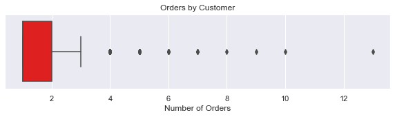

```python
# Auxiliary data frame for agregated variables by customer ID:
lst_cust = df['customer_id'].unique()
ord_cust = [df[df['customer_id']==cust]['order_id'].count() for cust in lst_cust]

agg_cust = pd.DataFrame({'customer': lst_cust, 'orders': ord_cust})
agg_cust['orders'] = agg_cust['orders'].astype(int)

plt.figure(figsize=(10,2))
sns.boxplot(data = agg_cust,
            x = 'orders',
            color = 'red')
plt.title('Orders by Customer')
plt.xlabel('Number of Orders')
plt.show()
```

```python
agg_cust.describe().T
```

|  | count | mean | std | min | 25% | 50% | 75% | max |
| --- | --- | --- | --- | --- | --- | --- | --- | --- |
| customer | 1200.00 | 177202.83 | 117661.96 | 1311.00 | 77543.00 | 133212.00 | 294304.00 | 405334.00 |
| orders | 1200.00 | 1.58 | 1.09 | 1.00 | 1.00 | 1.00 | 2.00 | 13.00 |

The auxiliary dataframe **"agg_cust"** helps understand the distribution of orders per customer. As the box plot shows, most customers placed just 1 to 3 orders (including the whisker of the plot), while there are a number of "outlier" customers, with 4 to 13 orders. The distribution of orders per customer is very right-skewed.

#### Restaurant Names (restaurant_name):

Univariate analysis for the column 'restaurant_name', means analyzing the number of orders per restaurant. As there are too many for a clean analysis, aggregating by restaurant and filtering the top 80% of orders, Pareto-style seems like a good practice.

```python
# Building an auxiliary Data Frame to study the performance of each restaurant
rest_lst = df['restaurant_name'].unique()
orders_rest = [df[df['restaurant_name']==rest]['order_id'].count() for rest in rest_lst]
agg_rest = pd.DataFrame({'restaurant': rest_lst, 'orders': orders_rest})

agg_rest = agg_rest.sort_values(by = 'orders', ascending = False).reset_index() # sorting from highest to lowest order qty
agg_rest.drop('index', axis=1, inplace=True) # dropping the old index
agg_rest['orders'] = agg_rest['orders'].astype(int)

# Filling new columns to help determine normalized performance and accumulated % of orders (to filter the top 80% later)
agg_rest['pct'] = np.zeros(len(rest_lst))
agg_rest['pct_ac'] = np.zeros(len(rest_lst)) # accumulated % of orders

par_tot = 0

for indx in range(len(rest_lst)):
    par_tot += agg_rest.loc[indx,'orders']
    agg_rest.loc[indx,'pct'] = agg_rest.loc[indx,'orders'] / df.shape[0] * 100
    agg_rest.loc[indx,'pct_ac'] = par_tot / df.shape[0] * 100
agg_rest[agg_rest['pct_ac']<=80] # selection of top restaurants by quantity of orders, for 80% of orders.
```

|  | restaurant | orders | pct | pct_ac |
| --- | --- | --- | --- | --- |
| 0 | Shake Shack | 219 | 11.54 | 11.54 |
| 1 | The Meatball Shop | 132 | 6.95 | 18.49 |
| 2 | Blue Ribbon Sushi | 119 | 6.27 | 24.76 |
| 3 | Blue Ribbon Fried Chicken | 96 | 5.06 | 29.82 |
| 4 | Parm | 68 | 3.58 | 33.40 |
| 5 | RedFarm Broadway | 59 | 3.11 | 36.51 |
| 6 | RedFarm Hudson | 55 | 2.90 | 39.41 |
| 7 | TAO | 49 | 2.58 | 41.99 |
| 8 | Han Dynasty | 46 | 2.42 | 44.42 |
| 9 | Blue Ribbon Sushi Bar & Grill | 44 | 2.32 | 46.73 |
| 10 | Nobu Next Door | 42 | 2.21 | 48.95 |
| 11 | Rubirosa | 37 | 1.95 | 50.90 |
| 12 | Sushi of Gari 46 | 37 | 1.95 | 52.85 |
| 13 | Momoya | 30 | 1.58 | 54.43 |
| 14 | Five Guys Burgers and Fries | 29 | 1.53 | 55.95 |
| 15 | Blue Ribbon Sushi Izakaya | 29 | 1.53 | 57.48 |
| 16 | Bareburger | 27 | 1.42 | 58.90 |
| 17 | Tamarind TriBeCa | 27 | 1.42 | 60.33 |
| 18 | Jack's Wife Freda | 25 | 1.32 | 61.64 |
| 19 | Sushi of Gari Tribeca | 24 | 1.26 | 62.91 |
| 20 | Chipotle Mexican Grill $1.99 Delivery | 23 | 1.21 | 64.12 |
| 21 | The Smile | 18 | 0.95 | 65.07 |
| 22 | ilili Restaurant | 18 | 0.95 | 66.02 |
| 23 | Cafe Mogador | 18 | 0.95 | 66.97 |
| 24 | Yama Japanese Restaurant | 18 | 0.95 | 67.91 |
| 25 | The Kati Roll Company | 16 | 0.84 | 68.76 |
| 26 | Sushi of Gari | 16 | 0.84 | 69.60 |
| 27 | Cafe Habana | 16 | 0.84 | 70.44 |
| 28 | P.J. Clarke's | 15 | 0.79 | 71.23 |
| 29 | J. G. Melon | 15 | 0.79 | 72.02 |
| 30 | Westville Hudson | 15 | 0.79 | 72.81 |
| 31 | Osteria Morini | 14 | 0.74 | 73.55 |
| 32 | Hill Country Fried Chicken | 14 | 0.74 | 74.29 |
| 33 | Empanada Mama (closed) | 13 | 0.68 | 74.97 |
| 34 | Vanessa's Dumplings | 13 | 0.68 | 75.66 |
| 35 | Burger Joint | 12 | 0.63 | 76.29 |
| 36 | S'MAC | 12 | 0.63 | 76.92 |
| 37 | Otto Enoteca Pizzeria | 12 | 0.63 | 77.56 |
| 38 | Melt Shop | 11 | 0.58 | 78.13 |
| 39 | Sushi Samba | 11 | 0.58 | 78.71 |
| 40 | Balthazar Boulangerie | 10 | 0.53 | 79.24 |
| 41 | Boqueria | 9 | 0.47 | 79.72 |

```python
top_80 = agg_rest[agg_rest['pct_ac']<=80].shape[0]
print (f'There are {len(rest_lst)} unique values for the column restaurant_name, of which {top_80} took about 80% of the orders.')
```

```
There are 178 unique values for the column restaurant_name, of which 42 took about 80% of the orders.
```

```python
agg_rest.tail(10) # Taking a look at the ones with the lowest quantity of orders taken
```

|  | restaurant | orders | pct | pct_ac |
| --- | --- | --- | --- | --- |
| 168 | Rohm Thai | 1 | 0.05 | 99.53 |
| 169 | Dig Inn Seasonal Market | 1 | 0.05 | 99.58 |
| 170 | Socarrat Paella Bar | 1 | 0.05 | 99.63 |
| 171 | Alidoro | 1 | 0.05 | 99.68 |
| 172 | Cipriani Le Specialita | 1 | 0.05 | 99.74 |
| 173 | Sushi Choshi | 1 | 0.05 | 99.79 |
| 174 | Dos Caminos Soho | 1 | 0.05 | 99.84 |
| 175 | La Follia | 1 | 0.05 | 99.89 |
| 176 | Philippe Chow | 1 | 0.05 | 99.95 |
| 177 | 'wichcraft | 1 | 0.05 | 100.00 |

It can be seen that 42 restaurants account for about 80% of orders, with only 4 restaurants having more than 90 orders each. The bottom 10 restaurants have only 1 order each.

Let's do some visualizations on the quantity of orders:

1. Bar plot for the number of orders by each of the top restaurants that make up to 50% of total orders;
2. Histogram for the new variable orders per restaurant;
3. Box plot for the same new variable;

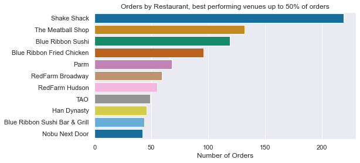

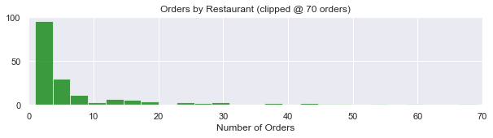

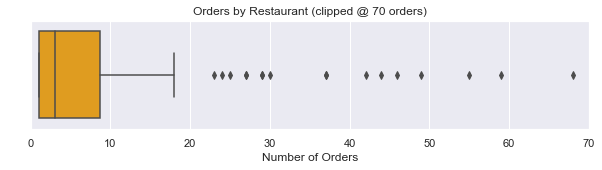

```python
plt.figure(figsize=(8,4))
sns.barplot(data = agg_rest[agg_rest['pct_ac']<=50],
            y = 'restaurant',
            x = 'orders',
            palette = 'colorblind')
plt.title('Orders by Restaurant, best performing venues up to 50% of orders')
plt.ylabel('')
plt.xlabel('Number of Orders')
plt.show()

plt.figure(figsize=(10,2))
sns.histplot(data = agg_rest,
             x = 'orders',
             color = 'green')
plt.xlim (0, 70) # limit to better visualize the main part of the distribution, that has a very long right tail
plt.title('Orders by Restaurant (clipped @ 70 orders)')
plt.ylabel('')
plt.xlabel('Number of Orders')
plt.show()

plt.figure(figsize=(10,2))
sns.boxplot(data = agg_rest,
            x = 'orders',
            color = 'orange')
plt.xlim (0, 70)
plt.title('Orders by Restaurant (clipped @ 70 orders)')
plt.ylabel(' ')
plt.xlabel('Number of Orders')
plt.show()
```

```python
agg_rest.describe(include = 'all').T
```

|  | count | unique | top | freq | mean | std | min | 25% | 50% | 75% | max |
| --- | --- | --- | --- | --- | --- | --- | --- | --- | --- | --- | --- |
| restaurant | 178 | 178 | Shake Shack | 1 | NaN | NaN | NaN | NaN | NaN | NaN | NaN |
| orders | 178.00 | NaN | NaN | NaN | 10.66 | 24.05 | 1.00 | 1.00 | 3.00 | 8.75 | 219.00 |
| pct | 178.00 | NaN | NaN | NaN | 0.56 | 1.27 | 0.05 | 0.05 | 0.16 | 0.46 | 11.54 |
| pct_ac | 178.00 | NaN | NaN | NaN | 85.64 | 17.63 | 11.54 | 81.24 | 92.49 | 97.67 | 100.00 |

A new variable, **orders per restaurant**, was created with the goal of getting a better understanding of the categorical variable 'restaurant_name'. As a byproduct, an interesting insight was found: orders per restaurant is extremely right-skewed, with about 75% of restaurants having less than 9 orders each, and half of them having no more than 3 orders.

#### Cuisine type (cuisine_type):

```python
cuis_txt = ", ".join(df.cuisine_type.unique())
print(f'There are {df.cuisine_type.nunique()} unique cuisine types in this data set: {cuis_txt}.')
```

```
There are 14 unique cuisine types in this data set: Korean, Japanese, Mexican, American, Indian, Italian, Mediterranean, Chinese, Middle Eastern, Thai, Southern, French, Spanish, Vietnamese.
```

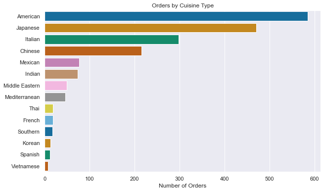

```python
plt.figure(figsize=(10,6))
sns.countplot(data = df,
              y = 'cuisine_type',
              palette = 'colorblind',
              order = df.cuisine_type.value_counts().index)
plt.title('Orders by Cuisine Type')
plt.ylabel('')
plt.xlabel('Number of Orders')
plt.show()
```

```python
print(df['cuisine_type'].value_counts().head(4), '\n')
print('Total:', sum(df['cuisine_type'].value_counts().head(4)), '\n')
print(df['cuisine_type'].value_counts(normalize=True).head(4)*100, '\n')
print('Total:', str(round(sum(df['cuisine_type'].value_counts(normalize=True).head(4)*100),1))+"%")
```

```
American    584
Japanese    470
Italian     298
Chinese     215
Name: cuisine_type, dtype: int64

Total: 1567

American   30.77
Japanese   24.76
Italian    15.70
Chinese    11.33
Name: cuisine_type, dtype: float64

Total: 82.6%
```

As the preceding bar plot shows, most orders are concentrated among a few cuisine types, with the top 4 being:

- American (584 orders, about 31%),
- Japanese (470 orders, about 25%),
- Italian (298 orders, about 16%) and
- Chinese (215 orders, about 11%).

These 4 cuisine types took 1567 orders, encompassing almost 83% of the 1898 total orders.

#### Cost of Orders (cost_of_the_order):

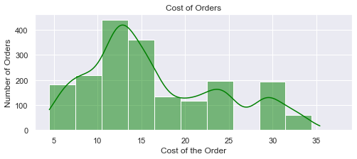

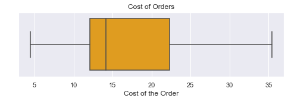

```python
plt.figure(figsize=(8,3))
sns.histplot(data = df,
             x = 'cost_of_the_order',
             color = 'green',
             binwidth = 3,
             kde = True)
plt.title('Cost of Orders')
plt.ylabel('Number of Orders')
plt.xlabel('Cost of the Order')
plt.show()

plt.figure(figsize=(8,2))
sns.boxplot(data = df,
            x = 'cost_of_the_order',
            color = 'orange')
plt.title('Cost of Orders')
plt.ylabel(' ')
plt.xlabel('Cost of the Order')
plt.show()
```

The distribution of this variable looks right-skewed. About 50 % of the orders are under the median of 14 dollars, while the average cost is 16.50 (from stats summary). Also, 50% of orders range between about 12 and 22 dollars. No outlier values observed.

#### Day of the Week (day_of_the_week):

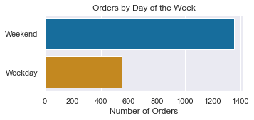

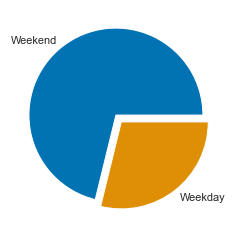

```python
plt.figure(figsize=(5,2))
sns.countplot(data = df,
              y = 'day_of_the_week',
              palette = 'colorblind')
plt.title('Orders by Day of the Week')
plt.ylabel('')
plt.xlabel('Number of Orders')
plt.show()

labels = df['day_of_the_week'].unique()
data = [df[df['day_of_the_week']==lab]['day_of_the_week'].count() for lab in labels]
expl = [0, 0.1]
palette_color = sns.color_palette('colorblind')
plt.pie(data,
        labels=labels,
        colors=palette_color,
        explode = expl)
plt.show() # A pie chart is added to better visualize proportions
```

```python
df.day_of_the_week.value_counts(normalize = True)
```

```
Weekend   0.71
Weekday   0.29
Name: day_of_the_week, dtype: float64
```

From the visuals and results above it can be concluded that almost 3/4 (71%) of the orders are placed on weekends.

#### Order ratings (rating and auxiliary column rating_value):

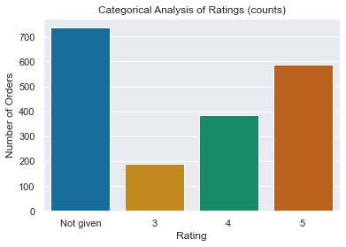

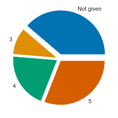

```python
sns.countplot(data = df,
              x = 'rating',
              palette = 'colorblind')
plt.title('Categorical Analysis of Ratings (counts)')
plt.ylabel('Number of Orders')
plt.xlabel('Rating')
plt.show()

labels = rat_cat
data = [df[df['rating']==lab]['rating'].count() for lab in labels]
expl = [0.1, 0.05, 0.05, 0.05]
palette_color = sns.color_palette('colorblind')
plt.pie(data,
        labels=labels,
        colors=palette_color,
        explode = expl)
plt.show() # A pie chart is added to better visualize proportions
```

```python
df.rating.value_counts(normalize = True)
```

```
Not given   0.39
5           0.31
4           0.20
3           0.10
Name: rating, dtype: float64
```

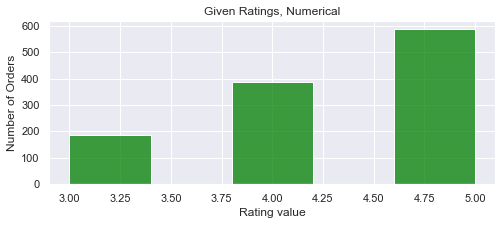

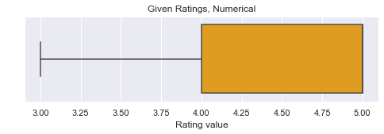

```python
# Visualization of auxiliary rating values column (only given ratings)
plt.figure(figsize=(8,3))
sns.histplot(data = df,
             x = 'rating_value',
             color = 'green',
             bins = 5)
plt.title('Given Ratings, Numerical')
plt.ylabel('Number of Orders')
plt.xlabel('Rating value')
plt.show()

plt.figure(figsize=(8,2))
sns.boxplot(data = df, x = 'rating_value', color = 'orange')
plt.title('Given Ratings, Numerical')
plt.ylabel(' ')
plt.xlabel('Rating value')
plt.show()
```

From these visualizations and results, the following insights can be obtained:

- A substantial proportion of the orders received no rating from the customer. At this point it can't be deducted if this means that the customer didn't want to rate the service, that the customer was displeased, or any other situation. This issue will be reassessed on the occasion of the multivariate analysis.
- Among the ratings given, about half were top rated (5).
- There are only "mediocre" to "very good" (our interpretation) ratings. No "bad" or "poor" ones (1 or 2), which could mean many of the "not given" ratings could indeed be situations where the customer was not pleased with the food or the service.
- From this outlook, it seems that customers are almost binary in their judgement of these type of services: it's either very good, or very bad, with relatively few nuances.
- The visualization of the numerical values is shown for reference, it adds just a little extra insights at this point. The position of the Q1 at rating = 4 means at least 75% of given ratings are 4 or 5. More usefulness is expected from this numerical variable during multivariate analysis.

A new column with an estimated "bad" value for ratings not given, will be created, to (informally) test if there's a relationship between variables that allows us to confirm the assumption that a significative quantity of orders with no ratings given are indeed bad experiences (will be used for the multivariate analysis).

```python
# new column in the df with "Not Given" ratings = 1.5
df['rating_value_est'] = df['rating'].replace(['Not given'], 1.5)
df['rating_value_est'] = df['rating_value_est'].astype(float)
```

#### Food Preparation Time (food_preparation_time):

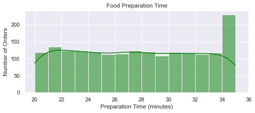

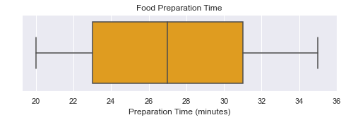

```python
plt.figure(figsize=(8,3)) # binwidth = 3
sns.histplot(data = df,
             x = 'food_preparation_time',
             color = 'green',
             binwidth = 1,
             kde = True)
plt.title('Food Preparation Time')
plt.ylabel('Number of Orders')
plt.xlabel('Preparation Time (minutes)')
plt.xticks(np.arange(20, 37, 2))
plt.show()

plt.figure(figsize=(8,2))
sns.boxplot(data = df, x = 'food_preparation_time', color = 'orange')
plt.title('Food Preparation Time')
plt.ylabel(' ')
plt.xlabel('Preparation Time (minutes)')
plt.xticks(np.arange(20, 37, 2))
plt.show()
```

As seen in the boxplot and the stats summary, about 50% of orders take between 23 and 31 minutes to be prepared. The median is 27 minutes and the mean is very close as per stats summary, at 27.37 minutes.

As a whole, the distribution looks almost uniform between 20 and 35 minutes, with an apparent "mode" that is product of a visualization glitch (34 and 35 min counted in the same bar). The kde curve helps detect this issue.

#### Food Delivery Time (delivery_time):

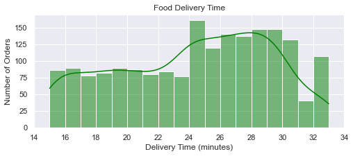

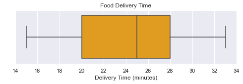

```python
plt.figure(figsize=(8,3))
sns.histplot(data = df,
             x = 'delivery_time',
             color = 'green',
             binwidth = 1,
             kde = True)
# plt.xlim (0, 80)
plt.title('Food Delivery Time')
plt.ylabel('Number of Orders')
plt.xlabel('Delivery Time (minutes)')
plt.xticks(np.arange(14, 35, 2))
plt.show()
plt.figure(figsize=(8,2))
sns.boxplot(data = df, x = 'delivery_time', color = 'orange')
# plt.xlim (0, 80)
plt.title('Food Delivery Time')
plt.ylabel(' ')
plt.xlabel('Delivery Time (minutes)')
plt.xticks(np.arange(14, 35, 2))
plt.show()
```

The distribution of delivery times is interesting: the variable distributes uniformly up until the 24 minutes mark, when it goes up in an apparent ladder step. The reason for this will be discussed in the multivariate analysis.

The distribution appears left skewed, with IQR between 20 and 28 minutes, a median of 25 minutes and an average of 24.16 minutes.

### **Question 7**: Which are the top 5 restaurants in terms of the number of orders received? [1 mark]

```python
# Write the code here
top_5_txt = ", ".join(agg_rest.head(5)['restaurant'])
top_5_ord = agg_rest.head(5)['orders'].sum()
print(f'The top 5 restaurants are: {top_5_txt}; with a total of {top_5_ord} orders.')
```

```
The top 5 restaurants are: Shake Shack, The Meatball Shop, Blue Ribbon Sushi, Blue Ribbon Fried Chicken, Parm; with a total of 634 orders.
```

#### Observations:

The auxiliary data frame created before (and which was already sorted by order quantities) helps to answer the question.

### **Question 8**: Which is the most popular cuisine on weekends? [1 mark]

```python
# Write the code here
df[df['day_of_the_week'] == 'Weekend']['cuisine_type'].value_counts(normalize = True).head(1)
```

```
American   0.31
Name: cuisine_type, dtype: float64
```

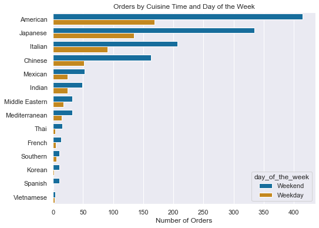

```python
plt.figure(figsize=(8,6))
sns.countplot(data = df,
              hue = 'day_of_the_week',
              y = 'cuisine_type',
              palette = 'colorblind',
              order = df.cuisine_type.value_counts().index)
plt.title('Orders by Cuisine Time and Day of the Week')
plt.ylabel('')
plt.xlabel('Number of Orders')
plt.show()
```

#### Observations:

Both the code and visual analysis confirm that American cuisine is the most popular on weekends, with a 31% of placed orders. In fact the overall top 4 types remain unchanged regardless of the day of the week.

### **Question 9**: What percentage of the orders cost more than 20 dollars? [2 marks]

```python
# Write the code here
od_over_20 = df[df['cost_of_the_order']>20].shape[0]
pc_over_20 = round(od_over_20/df.shape[0]*100, 2)
print(f'The proportion of orders costing more than 20 dollars is {pc_over_20}%, for a total of {od_over_20} orders.')
```

```
The proportion of orders costing more than 20 dollars is 29.24%, for a total of 555 orders.
```

#### Observations:

Almost 30% of orders amount to 20 dollars or more. It must be remembered that the distribution is right-skewed, so the bulk of orders are on the low cost side.

### **Question 10**: What is the mean order delivery time? [1 mark]

```python
# Write the code here
print(f'The mean order delivery time is {round(df.delivery_time.mean(), 2)} minutes')
```

```
The mean order delivery time is 24.16 minutes
```

#### Observations:

The answer is printed above. Informed insights about this variable are possible after the multivariate analysis below.

### **Question 11:** The company has decided to give 20% discount vouchers to the top 3 most frequent customers. Find the IDs of these customers and the number of orders they placed. [1 mark]

```python
# Write the code here
agg_cust.sort_values(by='orders', ascending=False).head(3)
```

|  | customer | orders |
| --- | --- | --- |
| 226 | 52832 | 13 |
| 242 | 47440 | 10 |
| 99 | 83287 | 9 |

#### Observations:

The auxiliary data frame created before helps to answer this question. The requested IDs and their respective number of orders are shown in the header displayed above.

### **Question 12**: Perform a multivariate analysis to explore relationships between the important variables in the dataset. (It is a good idea to explore relations between numerical variables as well as relations between numerical and categorical variables) [10 marks]

#### Finding relationships between numerical variables:

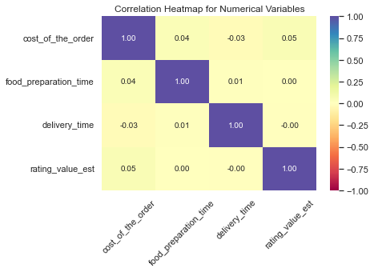

```python
# Write the code here
# First, it's convenient to try a correlation heatmap for numerical variables:
num_vars = ['cost_of_the_order', 'food_preparation_time', 'delivery_time', 'rating_value_est']

plt.figure(figsize=(6, 4))
sns.heatmap(df[num_vars].corr(),
            annot=True,
            vmin=-1,
            vmax=1,
            fmt=".2f",
            cmap="Spectral")
plt.title('Correlation Heatmap for Numerical Variables')
plt.xticks(rotation = 45)
plt.show()
```

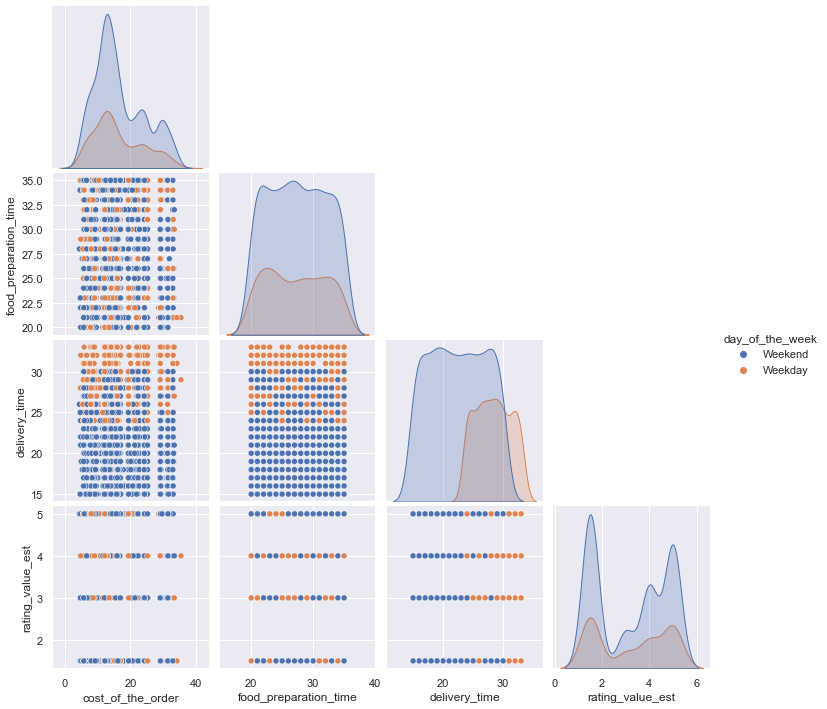

```python
# A pairplot helps to consolidate all the needed scatterplots to confirm the lack of correlations between numerical variables.
sel_vars = ['cost_of_the_order', 'day_of_the_week', 'food_preparation_time', 'delivery_time', 'rating_value_est']
sns.pairplot(df[sel_vars],
             hue = 'day_of_the_week',
             corner = True)
plt.show()
```

The heatmap and the pairplot don't show any significant correlation between the numerical variables (unless we introduce a categorical distinction). Using the day of the week as a categorical distinction helps hint a relationship between delivery time and this variable. This wasn't tried with the cuisine types, it would've been visually confusing.

#### Cost of the Orders vs Categories

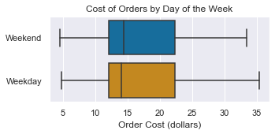

```python
plt.figure(figsize=(5, 2))
sns.boxplot(data = df,
            x = 'cost_of_the_order',
            y = 'day_of_the_week',
            palette = 'colorblind',
           )
plt.title('Cost of Orders by Day of the Week')
plt.ylabel('')
plt.xlabel('Order Cost (dollars)')
plt.show()
```

Almost no difference in the cost of the order between days of the week. What if we introduce cuisine type into the analysis?

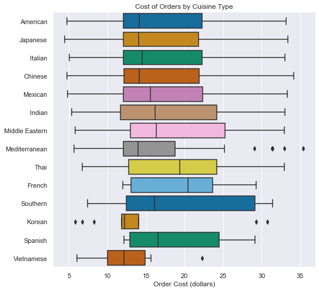

```python
plt.figure(figsize=(8, 8))
sns.boxplot(data = df,
            x = 'cost_of_the_order',
            y = 'cuisine_type',
            palette = 'colorblind',
            order = df.cuisine_type.value_counts().index
           )
plt.title('Cost of Orders by Cuisine Type')
plt.ylabel('')
plt.xlabel('Order Cost (dollars)')
plt.show()
```

The boxplot allows to observe that most cuisine types have similar ranges for their cost orders, with some nuances:

- The 4 best-performing cuisine types have a very similar median cost order, just below 15 dollars, and a bit lower than other competing cuisine types (Mexican, Indian and Middle-Eastern). Given that the 5th most ordered cuisine type (Mexican) is way far below the 4th place in quantity of orders, exploring the effect of prices on this (demand elasticity) seems worthy.
- Mediterranean cuisine orders are distributed with a greater right-skew than the rest, as the median cost of orders is almost the same as the most popular cuisine types, but with a long right tail that includes some outliers.
- Southern cuisine orders cost distribution have a very large IQR compared with other cuisine types.
- Median cost of orders of Thai and french cuisines appear noticeably higher than the rest.
- Korean and Vietnamese cuisine: most of their orders seem to be less costly than most other cuisine types, than includes both the median cost and the relative position of their IQR's.

Finally, it's important to mention that the apparent variability of worse performing cuisine types could be caused by the low quantities involved. It must be remembered that after the top 4 cuisine types, the quantity of orders drop dramatically.

#### Food Preparation Time vs Categories

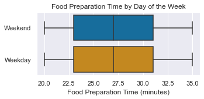

```python
plt.figure(figsize=(5, 2))
sns.boxplot(data = df,
            x = 'food_preparation_time',
            y = 'day_of_the_week',
            palette = 'colorblind',
           )
plt.title('Food Preparation Time by Day of the Week')
plt.ylabel('')
plt.xlabel('Food Preparation Time (minutes)')
plt.show()
```

The former graph confirms there is no relationship between day of the week and preparation time.

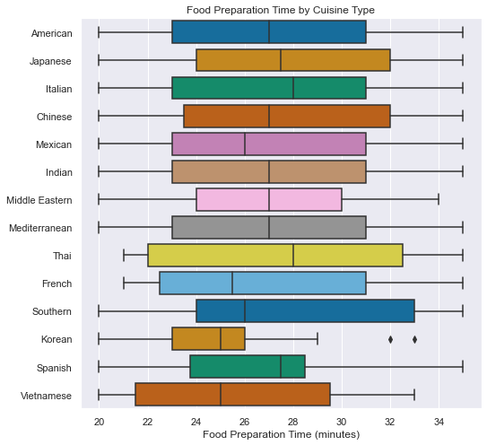

```python
plt.figure(figsize=(8, 8))
sns.boxplot(data = df,
            x = 'food_preparation_time',
            y = 'cuisine_type',
            palette = 'colorblind',
            order = df.cuisine_type.value_counts().index
           )
plt.title('Food Preparation Time by Cuisine Type')
plt.ylabel('')
plt.xlabel('Food Preparation Time (minutes)')
plt.show()
```

No big differences in preparation times between cuisines, most have median times between 26 and 28 minutes; save from a few examples with very little order quantities: French, Korean and Vietnamese seem to have slightly shorter median prep times.

As seen before, the preparation time distributes almost uniformly along its range. More research is needed in order to explain the spread of preparation time and improve (reduce) its variability, in order to give better waiting time estimates to the customer at the time of ordering.

The range of preparation time is limited, and it doesn't seem to have any relationship with the cost of the order or ratings.

#### Delivery Time vs Categories

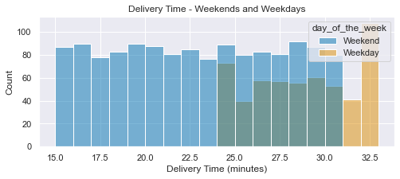

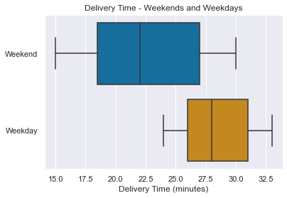

```python
plt.figure(figsize=(8, 3))
sns.histplot(data = df,
            x = 'delivery_time',
            hue = 'day_of_the_week',
            palette = 'colorblind',
            binwidth = 1
           )
plt.title('Delivery Time - Weekends and Weekdays')
plt.xlabel('Delivery Time (minutes)')
plt.show()

sns.boxplot(data = df,
            x = 'delivery_time',
            y = 'day_of_the_week',
            palette = 'colorblind',
        )
plt.title('Delivery Time - Weekends and Weekdays')
plt.ylabel('')
plt.xlabel('Delivery Time (minutes)')
plt.show()
```

There is a clear difference between weekends and week days in terms of delivery times. In fact, more than half of the week day orders take longer to deliver than 75% of weekend ones!

As the histogram shows, the "ladder" shape observed in the univariate analysis was due to the addition of weekends and weekdays in the same graph:

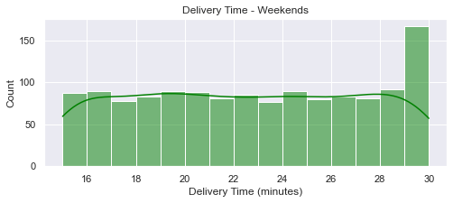

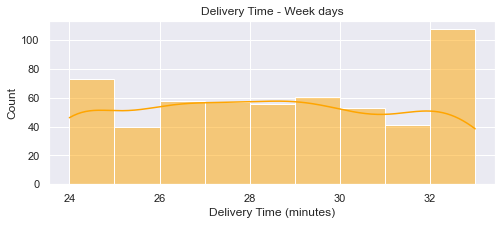

```python
plt.figure(figsize=(8, 3))
sns.histplot(data = df[df['day_of_the_week']=='Weekend'],
            x = 'delivery_time',
            color = 'green',
            binwidth = 1,
            kde = True
           )
plt.title('Delivery Time - Weekends')
plt.xlabel('Delivery Time (minutes)')
plt.show()

plt.figure(figsize=(8, 3))
sns.histplot(data = df[df['day_of_the_week']=='Weekday'],
            x = 'delivery_time',
            color = 'orange',
            binwidth = 1,
            kde = True
           )
plt.title('Delivery Time - Week days')
plt.xlabel('Delivery Time (minutes)')
plt.show()
```

Separate histograms for each category shows that the delivery time is distributed almost uniformly for each of them.

Differences between both categories could be due to less availability of delivery people or more traffic on weekdays.

More date/time and geographical information is needed to improve the analysis and eventually help make accurate predictions about waiting times for customers at the time of ordering.

#### Other categorical Analysis:

A new auxiliary data frame that aggregates data by cuisine type is created to help with further analysis:

```python
# aggregated data frame for cuisine types, for ratings and restaurant performance evaluation
cuis_list = df['cuisine_type'].unique()
ord_by_cuis = [df[df['cuisine_type']==cuis]['cuisine_type'].count() for cuis in cuis_list]
nul_rat = [df[df['cuisine_type']==cuis]['rating_value'].isnull().sum() for cuis in cuis_list]

agg_ct = pd.DataFrame({'cuisine':cuis_list,
                      'orders':ord_by_cuis,
                      'null_ratings':nul_rat}) # auxiliary dataframe

agg_ct['pc_nul_ratings'] = agg_ct['null_ratings'] / agg_ct['orders'] # proportion of not given ratings
agg_ct = agg_ct.sort_values(by='orders', ascending = False).reset_index()
agg_ct.drop('index', axis = 1, inplace = True)

cuis_ord = agg_ct.loc[:,'cuisine'] # auxiliary vector to add more columns

agg_ct['rest_n'] = [df[df['cuisine_type']==cuis]['restaurant_name'].nunique() for cuis in cuis_ord] # number of restaurants
agg_ct['ord_per_rest'] = agg_ct['orders'] / agg_ct['rest_n'] # orders per restaurant ratio
agg_ct.head()
```

|  | cuisine | orders | null_ratings | pc_nul_ratings | rest_n | ord_per_rest |
| --- | --- | --- | --- | --- | --- | --- |
| 0 | American | 584 | 216 | 0.37 | 41 | 14.24 |
| 1 | Japanese | 470 | 197 | 0.42 | 29 | 16.21 |
| 2 | Italian | 298 | 126 | 0.42 | 31 | 9.61 |
| 3 | Chinese | 215 | 82 | 0.38 | 16 | 13.44 |
| 4 | Mexican | 77 | 29 | 0.38 | 11 | 7.00 |

First, let's visualize the average rating by cuisine type, not considering ratings not given:

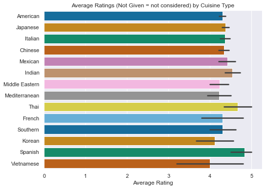

```python
plt.figure(figsize=(8, 6))
sns.barplot(data = df,
            x = 'rating_value', # column with 'Not Given' = null
            y = 'cuisine_type',
            palette = 'colorblind',
            order = df.cuisine_type.value_counts().index
           )
plt.title('Average Ratings (Not Given = not considered) by Cuisine Type')
plt.ylabel('')
plt.xlabel('Average Rating')
plt.show()
```

As can be seen, there are no great differences in average ratings. Nevertheless, Indian, Thai, and Spanish cuisines might have higher mean ratings. But the 'Not Given' values could be distorting the comparison:

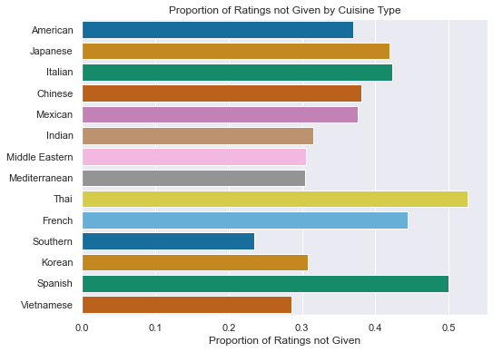

```python
plt.figure(figsize=(8, 6))
sns.barplot(data=agg_ct,
            x = 'pc_nul_ratings',
            y = 'cuisine',
            palette = 'colorblind')
plt.title('Proportion of Ratings not Given by Cuisine Type')
plt.ylabel('')
plt.xlabel('Proportion of Ratings not Given')
plt.show()
```

As can be seen from the former figure, there are differences by cuisine type in the proportion of ratings not given. This could affect the ratings comparative analysis. What would happen if we "punish" every cuisine type by using an estimated rating of 1.5 points when there is no rating?

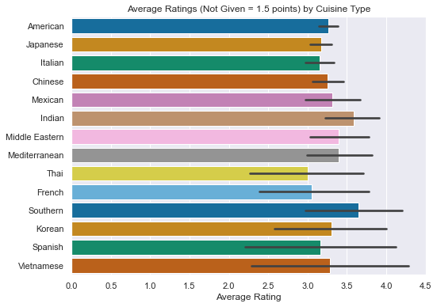

```python
plt.figure(figsize=(8, 6))
sns.barplot(data = df,
            x = 'rating_value_est', # column with 'Not Given' = 1.5
            y = 'cuisine_type',
            palette = 'colorblind',
            order = df.cuisine_type.value_counts().index
           )
plt.title('Average Ratings (Not Given = 1.5 points) by Cuisine Type')
plt.ylabel('')
plt.xlabel('Average Rating')
plt.show()
```

We could say that Indian and Southern cuisines look promising. Their performance could be very well due to both cuisines being a niche taste, lack of advertising effort, and/or other reasons.

Thai and French cuisines, among others, could have lower mean rating scores, but the low quantity and quality of the data doesn't allow for solid conclusions. In fact cuisines like Thai and Spanish may be very well received by the customers, more research is needed about the nature of the missing ratings to be able to make any solid conclusion about this variable. Also, the lower half of the graph shows cuisine types with very low quantity of orders, which could cause misleading results.